# Project: Investigate a Dataset (TMDb Movie Data)

- Introduction
- Data Wrangling
- Exploratory Data Analysis
- Conclusions

## Introduction

This is an analysis made for the project Investigate a Dataset. The dataset I chose for this analysis is TMDb data, which contains information about 10,000 movies collected fromThe Movie Database (TMDb), including user ratings and revenue.

We first import the required libraries for the analysis. Pandas is a Python data analysis and manipulation tool which will help us read the csv file and then proceed to analysis. Numpy is a Python library with a large collection of high-level mathematical functions which we gonna need during our research. We gonna need matplotlib in order to have good visualisations of our data. It is also improtant to import the magic function %inline just to be sure that our visualisations will show inline.

```python
import pandas as pd
import numpy as np
import matplotlib.pyplot as plt
import seaborn as sns

%matplotlib inline
```

## Data Wrangling

In this section we will load in the data, check for cleanliness, and then trim and clean the dataset for analysis. Data Wrangling is a very important part in every data analysis project.

### The problems that we abserve in this dataset are:

- Certain columns, like ‘cast’ and ‘genres’, contain multiple values separated by pipe (|) characters.
- The final two columns ending with “_adj” show the budget and revenue of the associated movie in terms of 2010 dollars, we will also delete those columns as we have 2020 now and 2010 dollars won't be a good practice to examine movies budget.
- The dataset contain lots of movies where the budget or revenue have a value of '0'.
- There are some duplicate rows that we will need to delete.

### General Properties

We read the dataset with pandas read_csv function and we inspect the first 5 rows of the dataset with tha function head(). We can see that the columns cast, genres, production_companies are separated with pipe and we will replace it later in the data cleaning section.

```python
df = pd.read_csv('tmdb-movies.csv')
df.head(5)
```

|  | id | imdb_id | popularity | budget | revenue | original_title | cast | homepage | director | tagline | ... | overview | runtime | genres | production_companies | release_date | vote_count | vote_average | release_year | budget_adj | revenue_adj |
| --- | --- | --- | --- | --- | --- | --- | --- | --- | --- | --- | --- | --- | --- | --- | --- | --- | --- | --- | --- | --- | --- |
| 0 | 135397 | tt0369610 | 32.985763 | 150000000 | 1513528810 | Jurassic World | Chris Pratt\|Bryce Dallas Howard\|Irrfan Khan\|Vi... | http://www.jurassicworld.com/ | Colin Trevorrow | The park is open. | ... | Twenty-two years after the events of Jurassic ... | 124 | Action\|Adventure\|Science Fiction\|Thriller | Universal Studios\|Amblin Entertainment\|Legenda... | 6/9/15 | 5562 | 6.5 | 2015 | 1.379999e+08 | 1.392446e+09 |
| 1 | 76341 | tt1392190 | 28.419936 | 150000000 | 378436354 | Mad Max: Fury Road | Tom Hardy\|Charlize Theron\|Hugh Keays-Byrne\|Nic... | http://www.madmaxmovie.com/ | George Miller | What a Lovely Day. | ... | An apocalyptic story set in the furthest reach... | 120 | Action\|Adventure\|Science Fiction\|Thriller | Village Roadshow Pictures\|Kennedy Miller Produ... | 5/13/15 | 6185 | 7.1 | 2015 | 1.379999e+08 | 3.481613e+08 |
| 2 | 262500 | tt2908446 | 13.112507 | 110000000 | 295238201 | Insurgent | Shailene Woodley\|Theo James\|Kate Winslet\|Ansel... | http://www.thedivergentseries.movie/#insurgent | Robert Schwentke | One Choice Can Destroy You | ... | Beatrice Prior must confront her inner demons ... | 119 | Adventure\|Science Fiction\|Thriller | Summit Entertainment\|Mandeville Films\|Red Wago... | 3/18/15 | 2480 | 6.3 | 2015 | 1.012000e+08 | 2.716190e+08 |
| 3 | 140607 | tt2488496 | 11.173104 | 200000000 | 2068178225 | Star Wars: The Force Awakens | Harrison Ford\|Mark Hamill\|Carrie Fisher\|Adam D... | http://www.starwars.com/films/star-wars-episod... | J.J. Abrams | Every generation has a story. | ... | Thirty years after defeating the Galactic Empi... | 136 | Action\|Adventure\|Science Fiction\|Fantasy | Lucasfilm\|Truenorth Productions\|Bad Robot | 12/15/15 | 5292 | 7.5 | 2015 | 1.839999e+08 | 1.902723e+09 |
| 4 | 168259 | tt2820852 | 9.335014 | 190000000 | 1506249360 | Furious 7 | Vin Diesel\|Paul Walker\|Jason Statham\|Michelle ... | http://www.furious7.com/ | James Wan | Vengeance Hits Home | ... | Deckard Shaw seeks revenge against Dominic Tor... | 137 | Action\|Crime\|Thriller | Universal Pictures\|Original Film\|Media Rights ... | 4/1/15 | 2947 | 7.3 | 2015 | 1.747999e+08 | 1.385749e+09 |

5 rows × 21 columns

```python
df.loc[df['original_title'] == 'Hamlet']
```

|  | id | imdb_id | popularity | budget | revenue | original_title | cast | homepage | director | tagline | ... | overview | runtime | genres | production_companies | release_date | vote_count | vote_average | release_year | budget_adj | revenue_adj |
| --- | --- | --- | --- | --- | --- | --- | --- | --- | --- | --- | --- | --- | --- | --- | --- | --- | --- | --- | --- | --- | --- |
| 1890 | 28238 | tt1449175 | 0.086490 | 0 | 0 | Hamlet | David Tennant\|Patrick Stewart\|Penny Downie\|Oli... | http://www.bbc.co.uk/hamlet/ | Gregory Doran | To be, or not to be? | ... | David Tennant stars in a film of the Royal Sha... | 185 | Drama | NHK Enterprises\|Illuminations\|BBC Wales | 12/26/09 | 13 | 6.4 | 2009 | 0.000000e+00 | 0.000000e+00 |
| 8573 | 10549 | tt0116477 | 0.383469 | 0 | 0 | Hamlet | Kenneth Branagh\|Derek Jacobi\|Julie Christie\|Ri... | NaN | Kenneth Branagh | NaN | ... | Hamlet, Prince of Denmark, returns home to fin... | 242 | Drama | Castle Rock Entertainment\|Turner Pictures (I) | 12/25/96 | 51 | 6.7 | 1996 | 0.000000e+00 | 0.000000e+00 |
| 8797 | 10688 | tt0171359 | 0.277798 | 2000000 | 1568749 | Hamlet | Ethan Hawke\|Kyle MacLachlan\|Diane Venora\|Sam S... | NaN | Michael Almereyda | Passion, Betrayal, Revenge, A hostile takeover... | ... | Modern day adaptation of Shakespeare's immorta... | 112 | Drama | Miramax Films\|double A Films | 5/12/00 | 18 | 5.0 | 2000 | 2.532584e+06 | 1.986494e+06 |
| 10106 | 10264 | tt0099726 | 0.067973 | 0 | 20710451 | Hamlet | Mel Gibson\|Glenn Close\|Alan Bates\|Paul Scofiel... | NaN | Franco Zeffirelli | The extraordinary adaptation of Shakespeare's ... | ... | Hamlet, Prince of Denmark, finds out that his ... | 130 | Drama\|History | Icon Productions\|Warner Bros. Pictures\|Nelson ... | 12/19/90 | 43 | 6.5 | 1990 | 0.000000e+00 | 3.456364e+07 |

4 rows × 21 columns

With the function duplicated we can find the duplicated rows that we will need to delete.

```python
sum(df.duplicated())
```

```
1
```

We will also print the last columns of the dataset in order to have a more specific picture of the data structure. We can see that there are movies with 0 budget_adj and 0 revenue_adj.

```python
df.tail(2)
```

|  | id | imdb_id | popularity | budget | revenue | original_title | cast | homepage | director | tagline | ... | overview | runtime | genres | production_companies | release_date | vote_count | vote_average | release_year | budget_adj | revenue_adj |
| --- | --- | --- | --- | --- | --- | --- | --- | --- | --- | --- | --- | --- | --- | --- | --- | --- | --- | --- | --- | --- | --- |
| 10864 | 21449 | tt0061177 | 0.064317 | 0 | 0 | What's Up, Tiger Lily? | Tatsuya Mihashi\|Akiko Wakabayashi\|Mie Hama\|Joh... | NaN | Woody Allen | WOODY ALLEN STRIKES BACK! | ... | In comic Woody Allen's film debut, he took the... | 80 | Action\|Comedy | Benedict Pictures Corp. | 11/2/66 | 22 | 5.4 | 1966 | 0.000000 | 0.0 |
| 10865 | 22293 | tt0060666 | 0.035919 | 19000 | 0 | Manos: The Hands of Fate | Harold P. Warren\|Tom Neyman\|John Reynolds\|Dian... | NaN | Harold P. Warren | It's Shocking! It's Beyond Your Imagination! | ... | A family gets lost on the road and stumbles up... | 74 | Horror | Norm-Iris | 11/15/66 | 15 | 1.5 | 1966 | 127642.279154 | 0.0 |

2 rows × 21 columns

We can see that there are 10866 rows and 21 columns in this dataset.

```python
df.shape
```

```
(10866, 21)
```

```python
df.isna().sum()
```

```
id                         0
imdb_id                   10
popularity                 0
budget                     0
revenue                    0
original_title             0
cast                      76
homepage                7930
director                  44
tagline                 2824
keywords                1493
overview                   4
runtime                    0
genres                    23
production_companies    1030
release_date               0
vote_count                 0
vote_average               0
release_year               0
budget_adj                 0
revenue_adj                0
dtype: int64
```

```python
df.info()
```

```
<class 'pandas.core.frame.DataFrame'>
RangeIndex: 10866 entries, 0 to 10865
Data columns (total 21 columns):
 #   Column                Non-Null Count  Dtype
---  ------                --------------  -----
 0   id                    10866 non-null  int64
 1   imdb_id               10856 non-null  object
 2   popularity            10866 non-null  float64
 3   budget                10866 non-null  int64
 4   revenue               10866 non-null  int64
 5   original_title        10866 non-null  object
 6   cast                  10790 non-null  object
 7   homepage              2936 non-null   object
 8   director              10822 non-null  object
 9   tagline               8042 non-null   object
 10  keywords              9373 non-null   object
 11  overview              10862 non-null  object
 12  runtime               10866 non-null  int64
 13  genres                10843 non-null  object
 14  production_companies  9836 non-null   object
 15  release_date          10866 non-null  object
 16  vote_count            10866 non-null  int64
 17  vote_average          10866 non-null  float64
 18  release_year          10866 non-null  int64
 19  budget_adj            10866 non-null  float64
 20  revenue_adj           10866 non-null  float64
dtypes: float64(4), int64(6), object(11)
memory usage: 1.7+ MB
```

```python
df.duplicated().sum()
```

```
1
```

We can see that we have a duplicated line in the column id

We can see that movie Hamlet appears 4 times. We will explore it furthermore in order to see if it is the same movie with different productions. There are 4 different movies with the title Hamlet.

```python
df.original_title.value_counts().head(1)
```

```
Hamlet    4
Name: original_title, dtype: int64
```

As we can see, the movie has the same title but the cast and release_date is different. So we gonna keep it for our analysis.

```python
df.loc[df['original_title'] == 'Hamlet']
```

|  | id | imdb_id | popularity | budget | revenue | original_title | cast | homepage | director | tagline | ... | overview | runtime | genres | production_companies | release_date | vote_count | vote_average | release_year | budget_adj | revenue_adj |
| --- | --- | --- | --- | --- | --- | --- | --- | --- | --- | --- | --- | --- | --- | --- | --- | --- | --- | --- | --- | --- | --- |
| 1890 | 28238 | tt1449175 | 0.086490 | 0 | 0 | Hamlet | David Tennant\|Patrick Stewart\|Penny Downie\|Oli... | http://www.bbc.co.uk/hamlet/ | Gregory Doran | To be, or not to be? | ... | David Tennant stars in a film of the Royal Sha... | 185 | Drama | NHK Enterprises\|Illuminations\|BBC Wales | 12/26/09 | 13 | 6.4 | 2009 | 0.000000e+00 | 0.000000e+00 |
| 8573 | 10549 | tt0116477 | 0.383469 | 0 | 0 | Hamlet | Kenneth Branagh\|Derek Jacobi\|Julie Christie\|Ri... | NaN | Kenneth Branagh | NaN | ... | Hamlet, Prince of Denmark, returns home to fin... | 242 | Drama | Castle Rock Entertainment\|Turner Pictures (I) | 12/25/96 | 51 | 6.7 | 1996 | 0.000000e+00 | 0.000000e+00 |
| 8797 | 10688 | tt0171359 | 0.277798 | 2000000 | 1568749 | Hamlet | Ethan Hawke\|Kyle MacLachlan\|Diane Venora\|Sam S... | NaN | Michael Almereyda | Passion, Betrayal, Revenge, A hostile takeover... | ... | Modern day adaptation of Shakespeare's immorta... | 112 | Drama | Miramax Films\|double A Films | 5/12/00 | 18 | 5.0 | 2000 | 2.532584e+06 | 1.986494e+06 |
| 10106 | 10264 | tt0099726 | 0.067973 | 0 | 20710451 | Hamlet | Mel Gibson\|Glenn Close\|Alan Bates\|Paul Scofiel... | NaN | Franco Zeffirelli | The extraordinary adaptation of Shakespeare's ... | ... | Hamlet, Prince of Denmark, finds out that his ... | 130 | Drama\|History | Icon Productions\|Warner Bros. Pictures\|Nelson ... | 12/19/90 | 43 | 6.5 | 1990 | 0.000000e+00 | 3.456364e+07 |

4 rows × 21 columns

We see the histogram of all the columns of the dataset. We will see more advanced plots in the data analysis section. Some of the variables may have strong correlation. We will explore it later. In the histograms is clear that there are many 0 values in the columns budget, revenue.

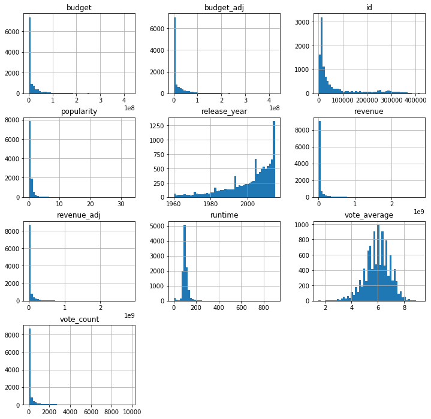

```python
df.hist(figsize = (12,12), bins=50);
```

Now we will se the number of 0s that we have in the budget and revenue column. We won't check other columns for now.

```python
print ('the number of 0s in budget are:', df[(df['budget']==0)].shape[0])
print ('the number of 0s in revenue are:', df[(df['revenue']==0)].shape[0])
```

```
the number of 0s in budget are: 5696
the number of 0s in revenue are: 6016
```

We can see that the dataset contains movies from 1960 to 2015. It would be nice to explore how budget, revenues and genre preferences changed through all those years. It would be also nice to find the correlation between budget and popularity as well as budget and revenue.

```python
# Preview stats for each columns
df.describe()
```

|  | id | popularity | budget | revenue | runtime | vote_count | vote_average | release_year | budget_adj | revenue_adj |
| --- | --- | --- | --- | --- | --- | --- | --- | --- | --- | --- |
| count | 10866.000000 | 10866.000000 | 1.086600e+04 | 1.086600e+04 | 10866.000000 | 10866.000000 | 10866.000000 | 10866.000000 | 1.086600e+04 | 1.086600e+04 |
| mean | 66064.177434 | 0.646441 | 1.462570e+07 | 3.982332e+07 | 102.070863 | 217.389748 | 5.974922 | 2001.322658 | 1.755104e+07 | 5.136436e+07 |
| std | 92130.136561 | 1.000185 | 3.091321e+07 | 1.170035e+08 | 31.381405 | 575.619058 | 0.935142 | 12.812941 | 3.430616e+07 | 1.446325e+08 |
| min | 5.000000 | 0.000065 | 0.000000e+00 | 0.000000e+00 | 0.000000 | 10.000000 | 1.500000 | 1960.000000 | 0.000000e+00 | 0.000000e+00 |
| 25% | 10596.250000 | 0.207583 | 0.000000e+00 | 0.000000e+00 | 90.000000 | 17.000000 | 5.400000 | 1995.000000 | 0.000000e+00 | 0.000000e+00 |
| 50% | 20669.000000 | 0.383856 | 0.000000e+00 | 0.000000e+00 | 99.000000 | 38.000000 | 6.000000 | 2006.000000 | 0.000000e+00 | 0.000000e+00 |
| 75% | 75610.000000 | 0.713817 | 1.500000e+07 | 2.400000e+07 | 111.000000 | 145.750000 | 6.600000 | 2011.000000 | 2.085325e+07 | 3.369710e+07 |
| max | 417859.000000 | 32.985763 | 4.250000e+08 | 2.781506e+09 | 900.000000 | 9767.000000 | 9.200000 | 2015.000000 | 4.250000e+08 | 2.827124e+09 |

### Data Cleaning (This is the part where the data set is prepared for the analysis and the data wrangling observations are being evaluated in the dataset)

Unfortunately, data is not always perfect (actually it is very rare to find perfect data). In this part of the project, we gonna apply the changes to the dataset and then we will begin the analysis. This part is very important on every data analysis because it improves data quality and increases overall productivity and results.

```python
#to see the exact names of the columns
df.columns
```

```
Index(['id', 'imdb_id', 'popularity', 'budget', 'revenue', 'original_title',
       'cast', 'homepage', 'director', 'tagline', 'keywords', 'overview',
       'runtime', 'genres', 'production_companies', 'release_date',
       'vote_count', 'vote_average', 'release_year', 'budget_adj',
       'revenue_adj'],
      dtype='object')
```

```python
df.drop(['id', 'budget_adj','revenue_adj','overview','imdb_id','homepage','tagline'],axis =1,inplace = True)
```

Inspect the dataset in order to confirm the removal of those columns.

```python
df.head(1)
```

|  | popularity | budget | revenue | original_title | cast | director | keywords | runtime | genres | production_companies | release_date | vote_count | vote_average | release_year |
| --- | --- | --- | --- | --- | --- | --- | --- | --- | --- | --- | --- | --- | --- | --- |
| 0 | 32.985763 | 150000000 | 1513528810 | Jurassic World | Chris Pratt\|Bryce Dallas Howard\|Irrfan Khan\|Vi... | Colin Trevorrow | monster\|dna\|tyrannosaurus rex\|velociraptor\|island | 124 | Action\|Adventure\|Science Fiction\|Thriller | Universal Studios\|Amblin Entertainment\|Legenda... | 6/9/15 | 5562 | 6.5 | 2015 |

1. We will now convert the release_date variable from string to datetime format.

```python
df['release_date'] = pd.to_datetime(df['release_date'])
df['release_date'].head()
```

```
0   2015-06-09
1   2015-05-13
2   2015-03-18
3   2015-12-15
4   2015-04-01
Name: release_date, dtype: datetime64[ns]
```

1. Ιt would also be a good idea to reorder the columns in order to have the title of the movie in column 1 and the other columns according to the importance for our research.

```python
#reespecting to confirm the changes.
df = df[['original_title', 'cast', 'director', 'production_companies', 'genres','release_year', 'release_date', 'popularity', 'runtime', 'vote_count', 'vote_average', 'budget', 'revenue', 'keywords']]
df.head(1)
```

|  | original_title | cast | director | production_companies | genres | release_year | release_date | popularity | runtime | vote_count | vote_average | budget | revenue | keywords |
| --- | --- | --- | --- | --- | --- | --- | --- | --- | --- | --- | --- | --- | --- | --- |
| 0 | Jurassic World | Chris Pratt\|Bryce Dallas Howard\|Irrfan Khan\|Vi... | Colin Trevorrow | Universal Studios\|Amblin Entertainment\|Legenda... | Action\|Adventure\|Science Fiction\|Thriller | 2015 | 2015-06-09 | 32.985763 | 124 | 5562 | 6.5 | 150000000 | 1513528810 | monster\|dna\|tyrannosaurus rex\|velociraptor\|island |

```python
#checking again the null values
df.isna().sum()
```

```
original_title             0
cast                      76
director                  44
production_companies    1030
genres                    23
release_year               0
release_date               0
popularity                 0
runtime                    0
vote_count                 0
vote_average               0
budget                     0
revenue                    0
keywords                1493
dtype: int64
```

```python
#replacing them with 0.
df.fillna(0, inplace = True)
```

Checking again to confirm the changes. We can confirm that we don't have any missing values after the replacing function.

```python
df.isna().sum()
```

```
original_title          0
cast                    0
director                0
production_companies    0
genres                  0
release_year            0
release_date            0
popularity              0
runtime                 0
vote_count              0
vote_average            0
budget                  0
revenue                 0
keywords                0
dtype: int64
```

```python
#df['budget'] = df['budget'].replace(0, np.NaN)
#df['revenue'] = df['revenue'].replace(0, np.NaN)

#df.dropna(inplace =True)
```

```python
print ('the number of 0s in budget are:', df[(df['budget']==0)].shape[0])
print ('the number of 0s in revenue are:', df[(df['revenue']==0)].shape[0])
```

```
the number of 0s in budget are: 5696
the number of 0s in revenue are: 6016
```

1. We will now rename some of the columns to a more specific name of our choice.

```python
df = df.rename({'original_title': 'title', 'runtime': 'duration', 'vote_count': 'votes', 'revenue':'profit'}, axis='columns')
```

Confirm one more time the changes. We will now have to replace the lamdas that appear in some column of the dataset.

```python
df.head(1)
```

|  | title | cast | director | production_companies | genres | release_year | release_date | popularity | duration | votes | vote_average | budget | profit | keywords |
| --- | --- | --- | --- | --- | --- | --- | --- | --- | --- | --- | --- | --- | --- | --- |
| 0 | Jurassic World | Chris Pratt\|Bryce Dallas Howard\|Irrfan Khan\|Vi... | Colin Trevorrow | Universal Studios\|Amblin Entertainment\|Legenda... | Action\|Adventure\|Science Fiction\|Thriller | 2015 | 2015-06-09 | 32.985763 | 124 | 5562 | 6.5 | 150000000 | 1513528810 | monster\|dna\|tyrannosaurus rex\|velociraptor\|island |

```python
df.head(1)
```

|  | title | cast | director | production_companies | genres | release_year | release_date | popularity | duration | votes | vote_average | budget | profit | keywords |
| --- | --- | --- | --- | --- | --- | --- | --- | --- | --- | --- | --- | --- | --- | --- |
| 0 | Jurassic World | Chris Pratt\|Bryce Dallas Howard\|Irrfan Khan\|Vi... | Colin Trevorrow | Universal Studios\|Amblin Entertainment\|Legenda... | Action\|Adventure\|Science Fiction\|Thriller | 2015 | 2015-06-09 | 32.985763 | 124 | 5562 | 6.5 | 150000000 | 1513528810 | monster\|dna\|tyrannosaurus rex\|velociraptor\|island |

## Exploratory Data Analysis

This is the part where we gonna investigate the dataset in order to analyse and visualize our findings. We will start by finding the most expensive movies, the movies with the biggest revenue. During the analysis we will try to visualize and solve different questions about this dataset.

### Question 1: Which are the most expensive movies? (based on movie budget)

In order to proceed our research we will explore the variables that we have in our dataset, finding the moste expensive movies, most popular movies and then we will proceed to the visualization part.

```python
max1 = df['budget'].max()
print ('According to our research, the movie with the biggest budget is The Warriors Way with a budget of :', max1)
```

```
According to our research, the movie with the biggest budget is The Warriors Way with a budget of : 425000000
```

```python
df.loc[df['budget'] == 425000000]
```

|  | title | cast | director | production_companies | genres | release_year | release_date | popularity | duration | votes | vote_average | budget | profit | keywords |
| --- | --- | --- | --- | --- | --- | --- | --- | --- | --- | --- | --- | --- | --- | --- |
| 2244 | The Warrior's Way | Kate Bosworth\|Jang Dong-gun\|Geoffrey Rush\|Dann... | Sngmoo Lee | Boram Entertainment Inc. | Adventure\|Fantasy\|Action\|Western\|Thriller | 2010 | 2010-12-02 | 0.25054 | 100 | 74 | 6.4 | 425000000 | 11087569 | assassin\|small town\|revenge\|deception\|super speed |

Here is a list with the movies with the biggest budget.

```python
df[['title', 'budget', 'release_year']].sort_values(by='budget', ascending=False).head(10)
```

|  | title | budget | release_year |
| --- | --- | --- | --- |
| 2244 | The Warrior's Way | 425000000 | 2010 |
| 3375 | Pirates of the Caribbean: On Stranger Tides | 380000000 | 2011 |
| 7387 | Pirates of the Caribbean: At World's End | 300000000 | 2007 |
| 14 | Avengers: Age of Ultron | 280000000 | 2015 |
| 6570 | Superman Returns | 270000000 | 2006 |
| 4411 | John Carter | 260000000 | 2012 |
| 1929 | Tangled | 260000000 | 2010 |
| 7394 | Spider-Man 3 | 258000000 | 2007 |
| 5508 | The Lone Ranger | 255000000 | 2013 |
| 4367 | The Hobbit: An Unexpected Journey | 250000000 | 2012 |

[figure not shown]

```python
profit_year = df.groupby('release_year')['budget'].sum()
sorted_budget = df['budget'].sort_values(ascending=False)[:20]
high_budget=pd.DataFrame()
titles_exp=[]
budgets=[]
for i in sorted_budget.index:
    titles_exp.append(df.loc[i,'title'])
    budgets.append(sorted_budget.loc[i])
high_budget['Titles']=titles_exp
high_budget['Budget']=budgets
high_budget.set_index('Titles',inplace=True)
high_budget.plot(kind ='bar',figsize=(10,10))
plt.title('Top 10 movies with the most budget ');
plt.ylabel('Budget in 100\'s of million');
```

The 10 most popular movies according our research and popularity rate column of the dataset.

```python
df[['title', 'release_year', 'popularity']].sort_values(by='popularity', ascending=False).head(10)
```

|  | title | release_year | popularity |
| --- | --- | --- | --- |
| 0 | Jurassic World | 2015 | 32.985763 |
| 1 | Mad Max: Fury Road | 2015 | 28.419936 |
| 629 | Interstellar | 2014 | 24.949134 |
| 630 | Guardians of the Galaxy | 2014 | 14.311205 |
| 2 | Insurgent | 2015 | 13.112507 |
| 631 | Captain America: The Winter Soldier | 2014 | 12.971027 |
| 1329 | Star Wars | 1977 | 12.037933 |
| 632 | John Wick | 2014 | 11.422751 |
| 3 | Star Wars: The Force Awakens | 2015 | 11.173104 |
| 633 | The Hunger Games: Mockingjay - Part 1 | 2014 | 10.739009 |